# Stock Predictions using Linear Regression and LSTM

## 1 Data Preperations

First we import quantmod which is the package used to import financial data from yahoo.finance. The ETF choosen is the S&P 500, which were selected as it has been relatively stable historically compared to smaller ETFs or funds. The aim is to make as great predictions as we know that noice is the primary factor which makes stock predictions so hard to develop. By selecting the S&P500 we hope that the noice is less than other options., Later on we might try this out on a gold or silver fund.

```
[1] "SPY"
```

```
           SPY.Open SPY.High  SPY.Low SPY.Close SPY.Volume SPY.Adjusted
2000-03-06 140.8125 141.3438 138.7500  139.7500   11967100     88.03426
2000-03-07 140.0000 140.1562 135.2188  137.0469   20062000     86.33145
2000-03-08 136.4688 137.8438 135.0312  136.8750   11808500     86.22318
2000-03-09 137.2500 140.8750 136.1250  140.8750    5500900     88.74292
2000-03-10 140.1875 142.0000 139.5312  140.1250    7924600     88.27048
2000-03-13 136.6875 140.4688 135.6875  138.5938   10540500     87.30591
```

```
           SPY.Open SPY.High SPY.Low SPY.Close SPY.Volume SPY.Adjusted
2026-03-05   682.08   685.53  675.61    681.31  106606500       681.31
2026-03-06   673.41   676.11  669.76    672.38  100687000       672.38
2026-03-09   666.39   679.92  662.39    678.27  102667700       678.27
2026-03-10   677.72   683.36  674.76    677.18   81505300       677.18
2026-03-11   677.58   680.08  673.34    676.33   68441700       676.33
2026-03-12   671.16   671.65  665.87    666.06  108493000       666.06
```

```
[1] 0
```

## 2 Feature Engineering

Next, In our dataset we already have open/close prices, high/low peak prices, order volume and adjusted return. We select closing price as our determinator och stock price and therefore drops open price. Volume is kept as it could potentially help the model identifie extreme scenarios like the 2008 financial crisis and other major event where the stock market moved a lot. The high and low peaks will be captured in the previous feature and are therefor dropped in the model as well. Furthermore adjusted return is removed because divedents, stock splits .i.e effects needs more information to be used in predictions other than what our data set brings.

```
              close   volume       return         SD    log_SD close_next
2000-04-03 151.2500  8508200  0.005818786 0.01683794 -4.084120   150.1250
2000-04-04 150.1250 19585500 -0.007438017 0.01616269 -4.125050   149.1875
2000-04-05 149.1875  8387200 -0.006244796 0.01629726 -4.116758   150.4844
2000-04-06 150.4844  6378500  0.008692920 0.01526815 -4.181987   151.4375
2000-04-07 151.4375  6023600  0.006333714 0.01513899 -4.190482   150.8438
2000-04-10 150.8438  9624200 -0.003920759 0.01485382 -4.209499   150.4062
```

The resulting dataset contains the explanatory variables close price, trading volume, daily return, and a 20-day rolling volatility measure. The target variable is the next day’s closing price (`close_next`). This formulation allows the models to learn how current market conditions relate to the following day’s price movement.

## 3 Explanatory Analysis

### 3.1 Price series

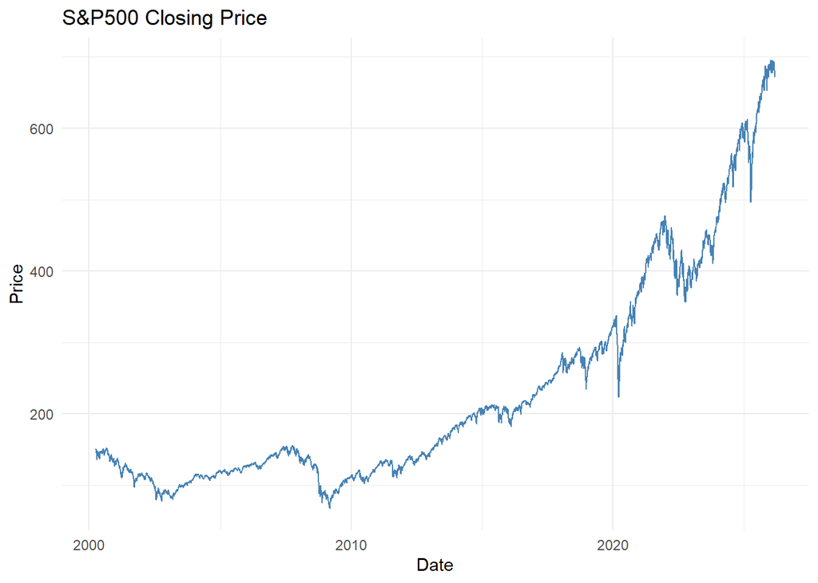

The figure shows the long-term upward trend of the S&P 500 index over the sample period. However, the series also exhibits clear periods of increased volatility, particularly during market stress events. Such dynamics make short-term price prediction challenging, as both trend and volatility change over time.

### 3.2 Returns

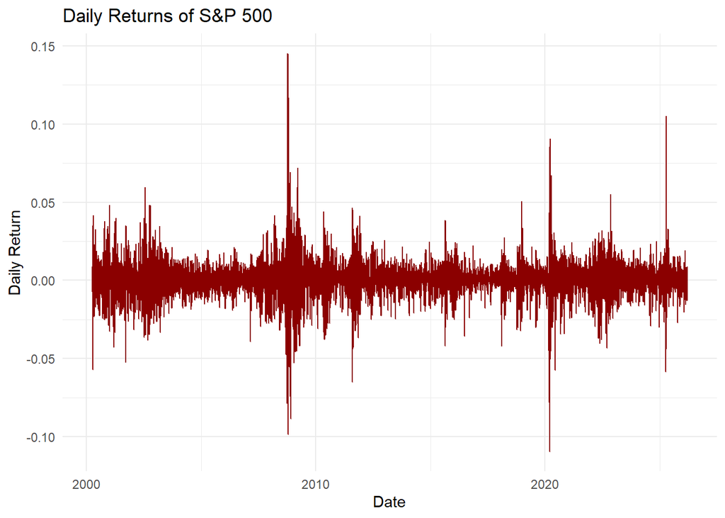

The return series fluctuates around zero and exhibits occasional large spikes. These spikes correspond to periods of market turbulence, where price changes are significantly larger than usual. Such behaviour is typical in financial markets and indicates the presence of volatility clustering.

### 3.3 Volatility

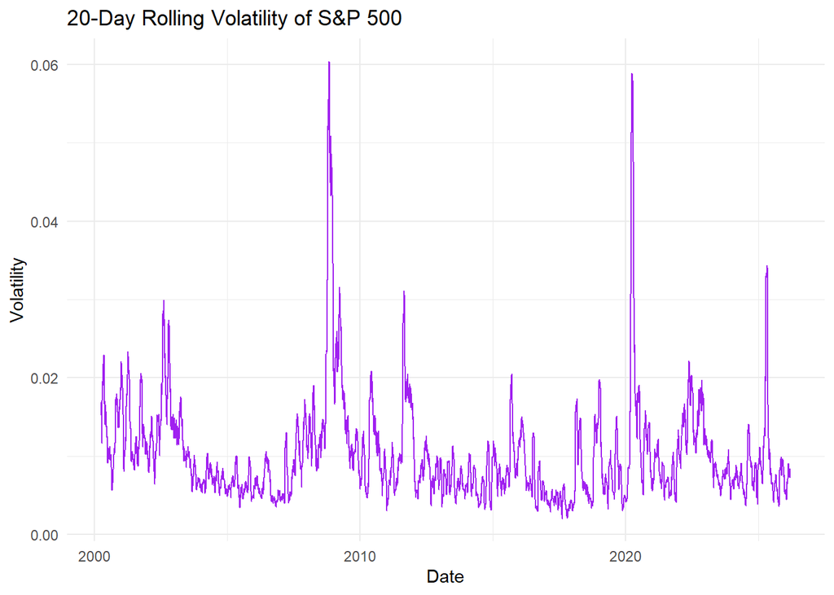

The rolling volatility plot illustrates how market risk varies over time. Periods of elevated volatility coincide with major market events and uncertainty. Including volatility as an explanatory variable allows the models to incorporate information about the current risk environment when predicting future prices.

### 3.4 Distribution of Returns

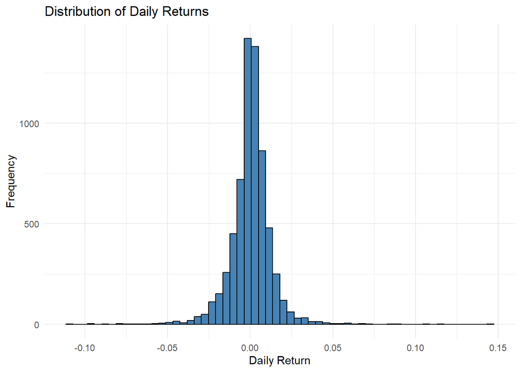

The histogram shows that daily returns are approximately centered around zero, but with heavier tails than a normal distribution. This implies that extreme price movements occur more frequently than would be expected under normality, which is a well-known characteristic of financial return series.

## 4 Linear Regression Benchmark

Linear regression is used as a baseline model to evaluate how well relatively simple statistical methods can predict stock prices. While financial markets are complex and often nonlinear, linear models provide a useful benchmark for comparison. By first estimating simple models, it becomes easier to evaluate whether more advanced machine learning approaches actually provide meaningful improvements.

Two walk-forward validation approaches are implemented: an expanding window model and a rolling window model. These methods mimic how forecasting would be performed in practice, where models are continuously re-estimated as new information becomes available.

#### 4.0.1 Expanding Window Model

The expanding window model gradually increases the amount of training data as time progresses. This approach assumes that all historical observations contain useful information for predicting future prices. In contrast, the rolling window model focuses only on the most recent observations by keeping a fixed training window while discarding older data.

#### 4.0.2 Rolling Window Model

The rolling window approach can be particularly useful in financial markets where structural changes occur frequently. Market regimes, volatility environments, and investor behavior may shift over time, meaning that very old data may no longer be representative of current conditions.

### 4.1 Evaluation of Linear Models

The linear regression models are evaluated using both error-based and direction-based measures. RMSE and MAE are used to assess how closely the predicted prices match the realized prices, while directional accuracy is used to evaluate whether the model correctly predicts the sign of the next market movement. This combination provides a broader picture of model performance, since a model may produce relatively small prediction errors without necessarily improving its ability to predict the correct direction of the market.

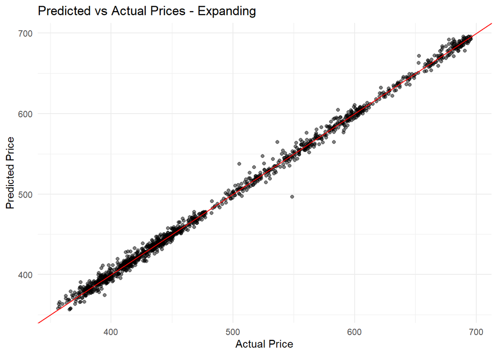

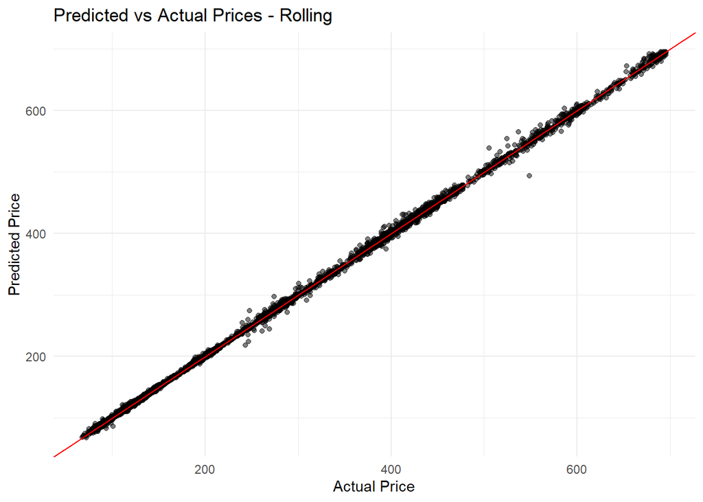

The scatterplot compares predicted and actual prices. Most observations lie close to the 45-degree line, indicating that the model predictions closely match the observed values. This result is partly explained by the strong autocorrelation in equity prices, where today’s price provides substantial information about tomorrow’s price.

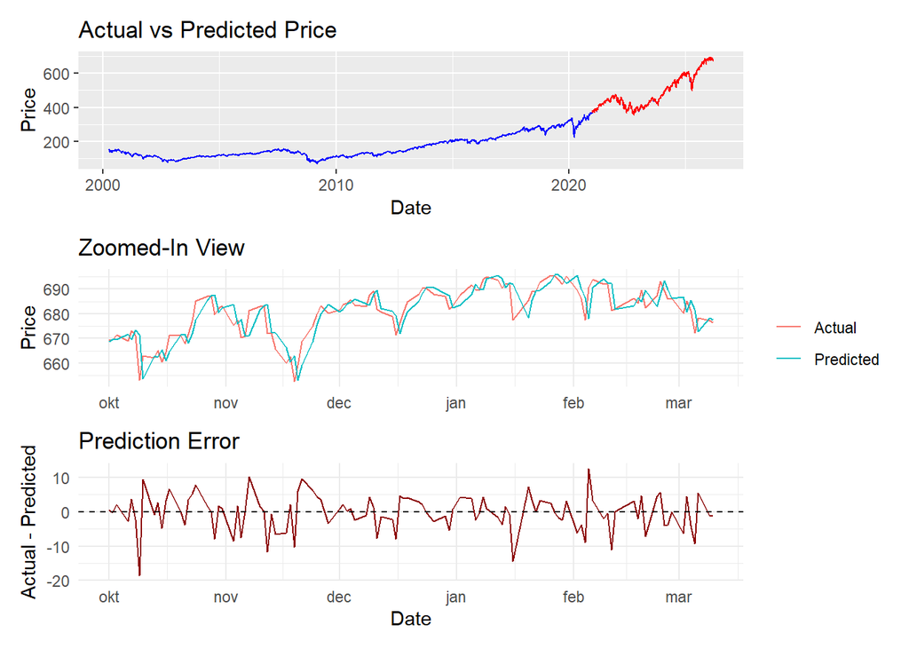

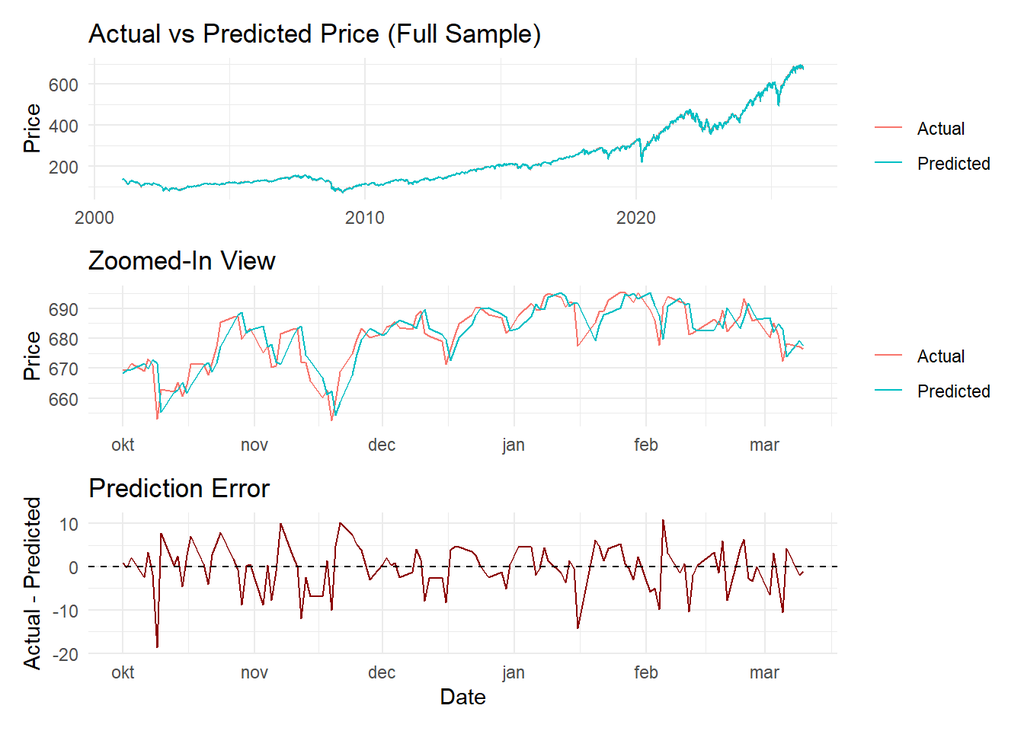

The zoomed-in plot provides a clearer view of the differences between predicted and actual prices. Although the predicted series follows the general price movement closely, small deviations can be observed. The prediction error plot highlights these deviations more clearly by displaying the difference between the actual and predicted values over time.

### 4.2 Directional Accuracy of the Linear models

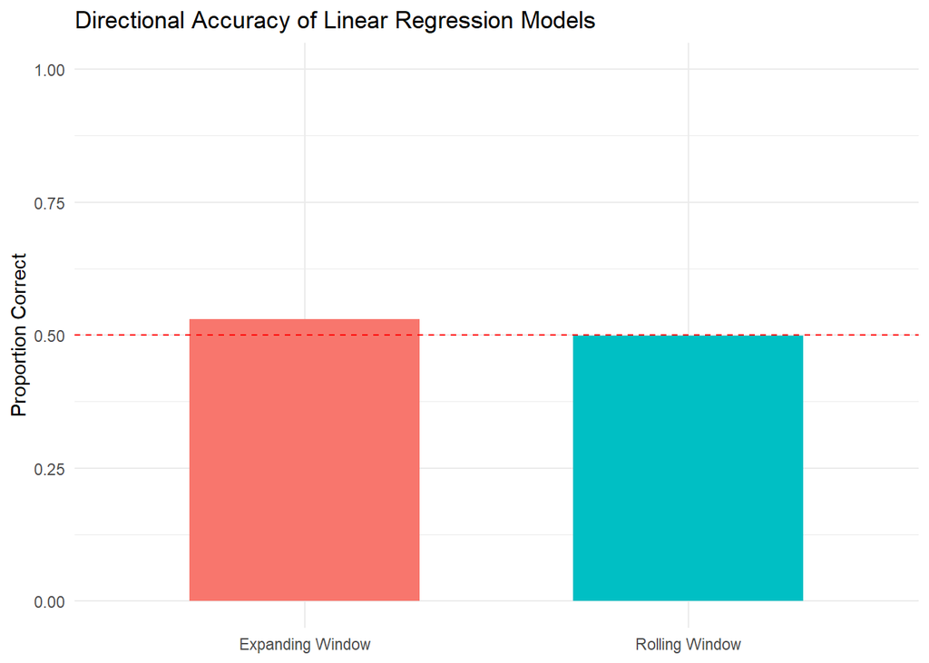

The directional accuracy of the linear regression models is only slightly above 50 percent for the expanding window model and approximately equal to random guessing for the rolling window specification. This result suggests that predicting the direction of daily market movements is extremely challenging using simple linear models.

However, directional accuracy alone does not provide a complete picture of model performance. Even if a model struggles to consistently predict whether the market will move up or down, it may still produce useful predictions in terms of price levels and prediction errors.

Therefore, the analysis proceeds by focusing on model stability and the magnitude of prediction errors rather than directional accuracy alone. In particular, attention is given to the volatility variable used in the regression model. Because financial volatility measures are strictly positive and often highly skewed, extreme observations may have a disproportionate influence on the regression estimates.

To mitigate this issue, a logarithmic transformation of the volatility measure is introduced. The rolling window regression is therefore re-estimated using log-transformed volatility (log_SD) as an explanatory variable. This transformation reduces the influence of extreme volatility spikes and can potentially improve the stability of the regression model.

```
                    Model RMSE  MAE
1        Expanding Window 5.06 3.59
2          Rolling Window 3.03 1.79
3 Rolling Window (log SD) 3.01 1.79
```

The results show a clear difference in predictive performance between the expanding and rolling window approaches. The expanding window model produces the highest error values, with an RMSE of 5.06 and an MAE of 3.59. This suggests that using all past observations in the training set may reduce the model’s ability to adapt to more recent market dynamics. In contrast, the rolling window specification performs substantially better, reducing the RMSE to 3.03 and the MAE to 1.79. This indicates that limiting the training data to a fixed, more recent window allows the model to better capture short-term patterns in the time series.

When replacing the volatility variable with its logarithmic transformation, the performance changes only marginally. The rolling window model with log-transformed volatility produces an RMSE of 3.01 and the same MAE of 1.79. Although this represents a slight improvement in RMSE, the difference is extremely small and does not materially change the predictive accuracy of the model.

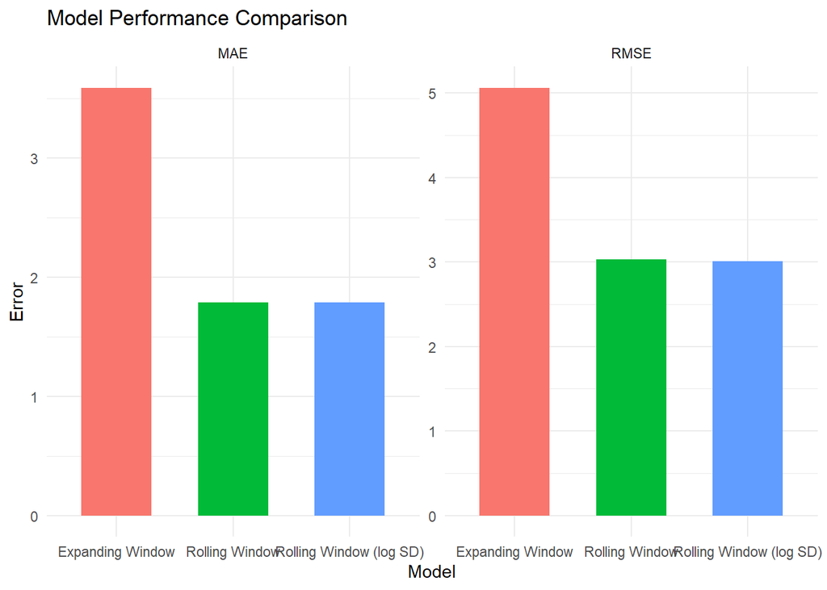

The performance comparison indicates that the rolling window model achieves lower prediction errors than the expanding window model. This suggests that more recent observations contain more relevant information for predicting short-term market movements, while older observations may reduce predictive accuracy when market conditions change over time.

### 4.3 Conclusions from the Linear Models

While the linear regression models provide a useful benchmark, the results indicate several limitations when applied to financial time series. The expanding window model shows slightly higher directional accuracy, suggesting that using the full historical sample may help capture the general direction of price movements. However, the rolling window model achieves substantially lower prediction errors (RMSE and MAE), indicating that predictions are more stable and closer to the actual price levels. This suggests that recent observations may contain more relevant information for short-term forecasting, while older observations can introduce noise as market conditions evolve over time.

Furthermore, introducing a log transformation of the volatility variable (standard deviation) leads to only a very small improvement in RMSE and no noticeable change in MAE. This suggests that the transformation slightly stabilizes the model but does not materially improve its predictive performance. Overall, the results indicate that the choice of windowing strategy has a much larger impact on model accuracy than the log transformation of volatility.

From a practical perspective, minimizing prediction error may be more important than slightly improving directional accuracy. In many real-world trading strategies, such as options trading or short positions, the magnitude of prediction errors can significantly affect profitability. For example, if predictions are used to structure option positions (such as buying put options or taking short exposure), large forecast errors could lead to incorrect position sizing and increased risk. In such cases, a model that produces smaller and more stable prediction errors may be preferable even if its directional accuracy is slightly lower.

The relatively strong performance of the linear regression models when predicting price levels should although be interpreted with caution. Financial asset prices typically exhibit strong autocorrelation, meaning that tomorrow’s price is often very close to today’s price. As a result, even simple models can produce predictions that appear accurate when evaluated in terms of price levels. In fact, a naive forecasting rule that simply predicts tomorrow’s price to be equal to today’s price can already achieve relatively small prediction errors.

This characteristic of financial time series explains why the regression models produce predictions that closely track the observed prices, while still showing limited ability to predict the direction of daily price movements.

## 5 LSTM modeling

### 5.1 Motivation for Using LSTM

While linear regression provides a useful benchmark, financial time series often exhibit nonlinear relationships, temporal dependencies, and regime changes that simple linear models may fail to capture. Long Short-Term Memory (LSTM) networks are specifically designed to handle sequential data and learn complex temporal patterns. Unlike traditional regression models, LSTM networks can capture nonlinear interactions between variables and incorporate information from multiple previous observations through their memory structure.

### 5.2 Feature Scaling

Before training the LSTM model, the input features were scaled using min–max normalization. Neural networks generally perform better when input variables are on a similar scale, as large differences in magnitude between variables can negatively affect the training process and slow down convergence. In this study, the variables *close*, *volume*, *return*, and *SD* were rescaled to the interval [0,1] using min–max scaling. This transformation preserves the relative relationships in the data while ensuring that all features contribute proportionally during model training.

### 5.3 Rolling Window LSTM Procedure

To maintain a realistic forecasting setup, the LSTM model is estimated using a rolling window framework. At each estimation step, the model is trained using the most recent observations within the selected window. The model uses sequences of 20 past observations (lookback window) to predict the next day’s price.

To reduce computational time, the model is not re-estimated at every time step. Instead, the estimation is performed at fixed intervals of 10 observations. This means that the model generates one-step-ahead forecasts only every tenth day, rather than daily predictions. At each estimation step, the network is trained for 8 epochs before producing the next forecast.

After defining the rolling window LSTM function, the model is applied to the dataset to generate out-of-sample predictions. The model is trained repeatedly using the most recent 200 observations and then used to predict the next day’s closing price. For each prediction step, the LSTM network is trained using sequences of length 20 constructed from the explanatory variables. This procedure produces a series of rolling forecasts that can later be compared to the actual observed values. The resulting predictions are stored together with the corresponding dates and actual values, enabling a direct evaluation of the model’s forecasting performance.

The model is implemented using the Keras library and executed through a Python virtual environment via the R package reticulate.

```
virtualenv: r-lstm
```

```
Using virtual environment "r-lstm" ...
```

```
          date   actual     pred      error
201 2001-01-18 134.0156 141.1878  -7.172199
211 2001-02-01 134.8000 141.5582  -6.758172
221 2001-02-15 130.4000 136.8257  -6.425752
231 2001-03-02 124.7400 141.0115 -16.271479
241 2001-03-16 117.3500 148.2128 -30.862812
251 2001-03-30 114.2000 141.2800 -27.079992
```

```
           date actual     pred     error
6471 2025-12-23 690.38 599.1188 91.261224
6481 2026-01-08 694.07 668.7805 25.289476
6491 2026-01-23 692.73 628.2725 64.457479
6501 2026-02-06 693.95 646.2446 47.705374
6511 2026-02-23 687.35 638.9672 48.382816
6521 2026-03-09 677.18 680.8039 -3.623872
```

### 5.4 LSTM Results

The LSTM results illustrate both the potential and the limitations of machine learning models in financial forecasting. While the model is able to capture the overall price dynamics and produce forecasts that broadly follow the observed trend, prediction errors remain substantial.

This outcome is consistent with the broader literature on financial forecasting. Financial markets are influenced by a wide range of unpredictable factors, including macroeconomic events, investor sentiment, policy decisions, and unexpected shocks. As a result, even advanced machine learning models often struggle to produce highly accurate short-term forecasts.

Nevertheless, the LSTM model demonstrates that nonlinear models can capture certain temporal patterns in financial time series that simpler models may overlook as we can see in the beginning of the plots as the market where less volatile.

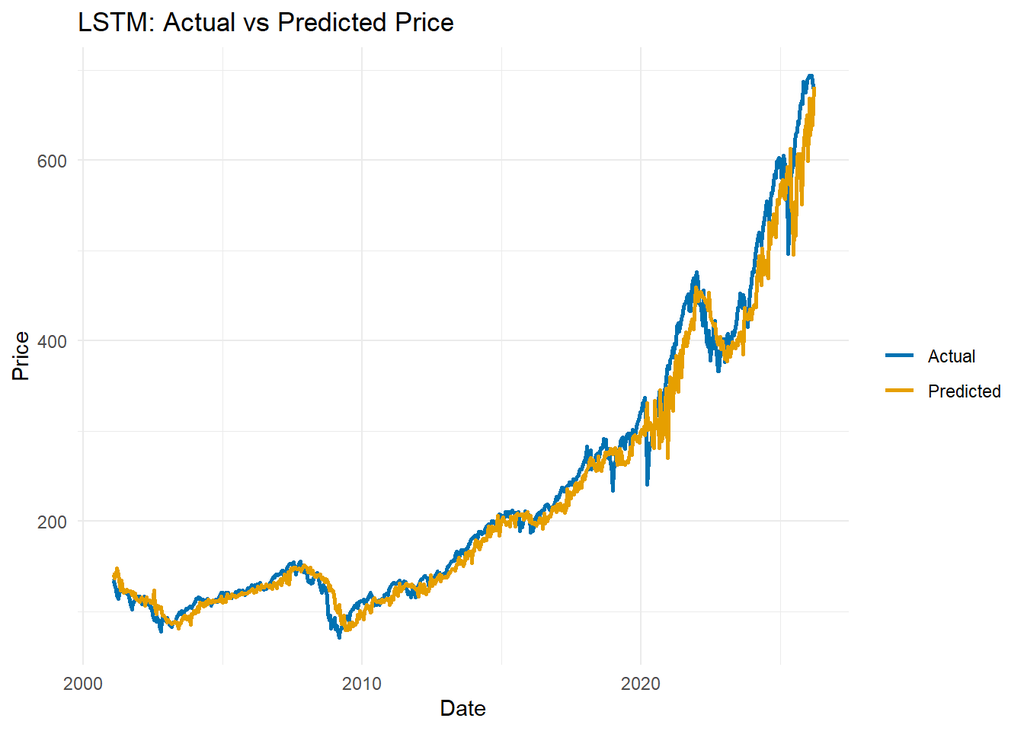

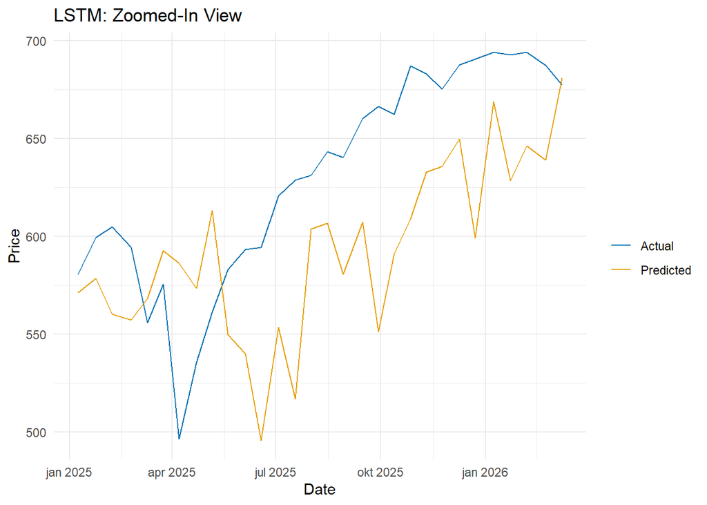

```
[1] 15.98376
```

```
[1] 23.7296
```

```
MAE: 15.98376
```

```
RMSE: 23.7296
```

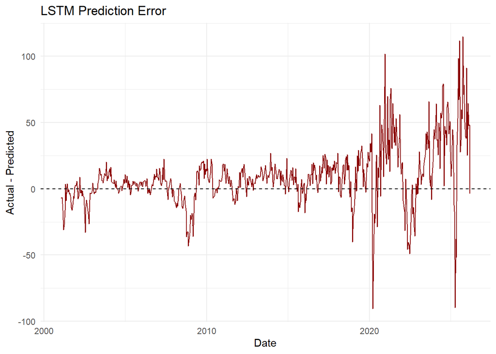

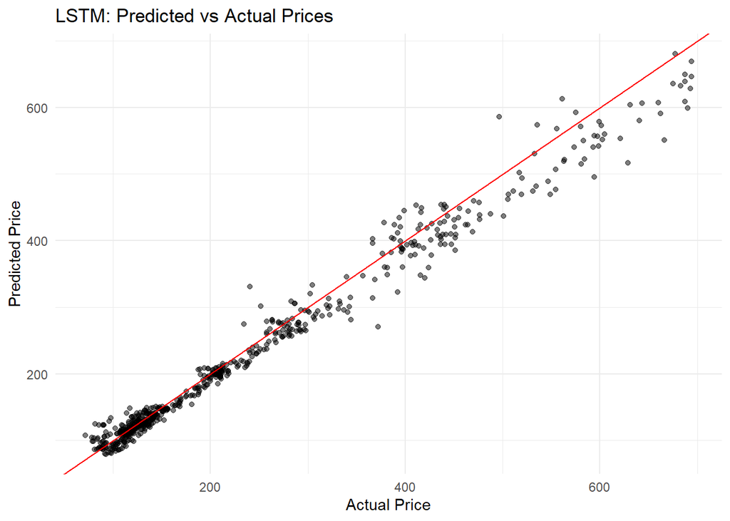

The scatterplot shows that most predicted values lie close to the 45-degree line, indicating that the LSTM model captures the overall level of the index reasonably well. This pattern is partly explained by the strong autocorrelation in equity prices, where tomorrow’s price is typically close to today’s price.

However, the dispersion around the line increases for higher price levels. This can be linked to the increasing volatility observed in the descriptive analysis of the time series. As market volatility rises, particularly during periods of financial stress, price movements become larger and more difficult to predict. Consequently, prediction errors tend to increase during these periods, which explains the wider spread of observations in the upper range of the plot.

This observation highlights an important characteristic of financial forecasting: models may track the general price level relatively well, but prediction accuracy tends to deteriorate when market volatility increases as we can see in all of the plots.

```
[1] 0.4660348
```

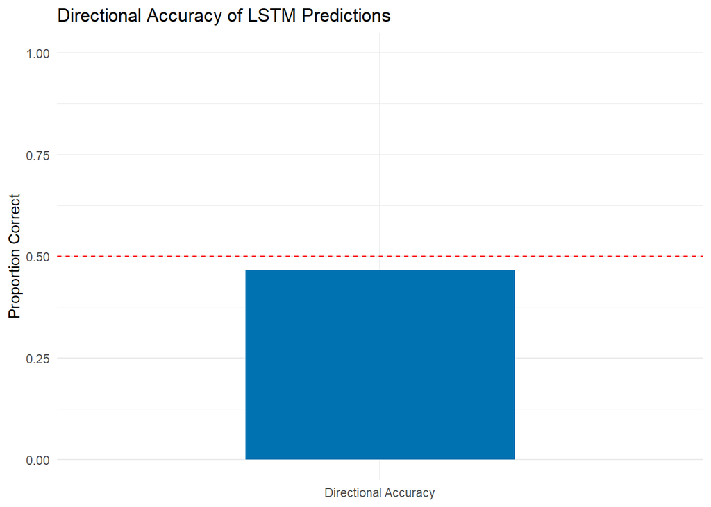

The directional accuracy of the first LSTM model is approximately 0.46, which is close to random guessing. This suggests that although the model captures the general price dynamics of the index, predicting the direction of daily market movements remains difficult.

### 5.5 Rolling Window LSTM (5-Year Model)

To further examine the predictive performance of the LSTM model, an alternative specification is estimated using only the most recent five years of observations. Financial markets evolve over time, and limiting the training data to more recent periods may allow the model to better adapt to current market dynamics.

The model is estimated using a rolling window framework with a fixed window size of 250 observations, which approximately corresponds to one trading year. At each estimation step, the model is trained using the most recent observations within the selected window. Input sequences consist of 20 past observations (lookback window), which are used to predict the next day’s closing price.

Unlike the previous LSTM specification, the model is re-estimated at every time step, meaning that a new prediction is generated for each trading day. This produces a full sequence of one-step-ahead forecasts across the five-year sample.

Another modification concerns the scaling procedure applied to the input variables. Instead of min–max normalization, the explanatory variables are standardized using z-score scaling. This transformation centers the variables around their mean and scales them by their standard deviation, which can improve numerical stability during neural network training.

At each rolling step, the LSTM network is trained for 20 epochs with a batch size of 16. The network architecture consists of a single LSTM layer with 30 hidden units, followed by a dropout layer to reduce the risk of overfitting and a dense output layer that produces the final price prediction. Learning rate is still default i.e 0.001.

```
          date actual     pred
251 2022-03-07 416.25 446.9510
252 2022-03-08 427.41 458.1500
253 2022-03-09 425.48 459.0144
254 2022-03-10 420.07 452.3788
255 2022-03-11 417.00 453.5655
256 2022-03-14 426.17 457.9327
```

```
           date actual     pred
1250 2026-03-02 680.33 629.2507
1251 2026-03-03 685.13 628.6206
1252 2026-03-04 681.31 611.0763
1253 2026-03-05 672.38 605.0231
1254 2026-03-06 678.27 646.2221
1255 2026-03-09 677.18 620.4665
```

```
          date actual     pred
251 2022-03-07 416.25 446.9510
252 2022-03-08 427.41 458.1500
253 2022-03-09 425.48 459.0144
254 2022-03-10 420.07 452.3788
255 2022-03-11 417.00 453.5655
256 2022-03-14 426.17 457.9327
```

```
           date actual     pred
1250 2026-03-02 680.33 629.2507
1251 2026-03-03 685.13 628.6206
1252 2026-03-04 681.31 611.0763
1253 2026-03-05 672.38 605.0231
1254 2026-03-06 678.27 646.2221
1255 2026-03-09 677.18 620.4665
```

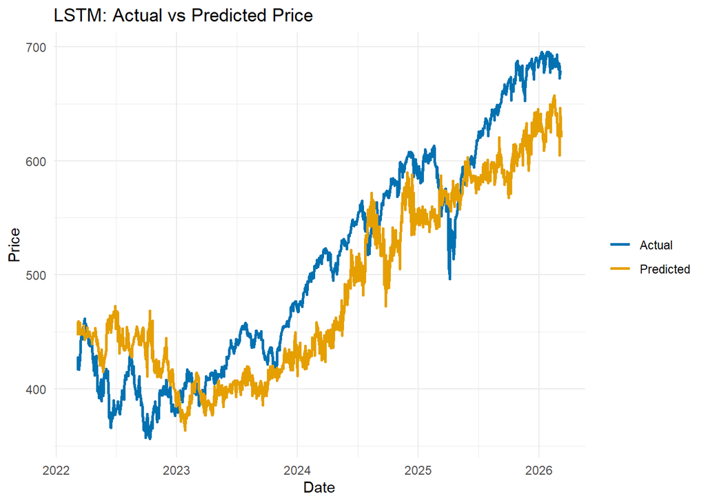

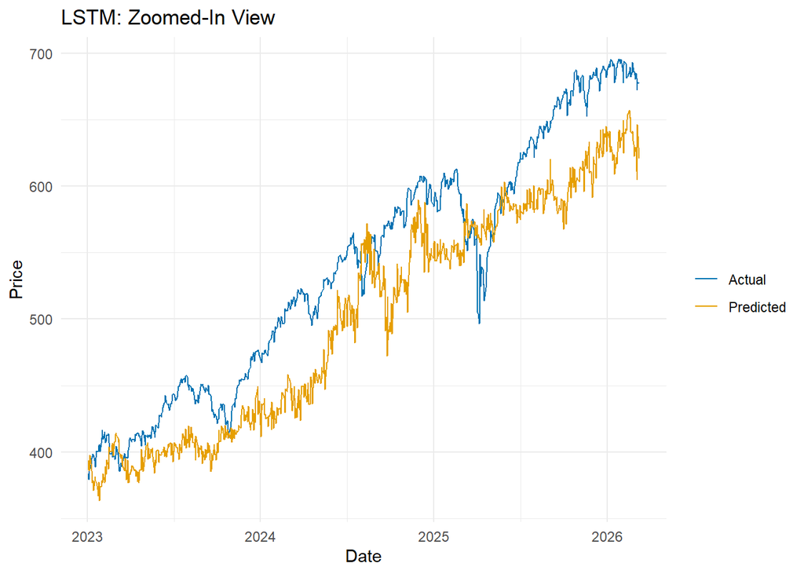

```
[1] 40.22419
```

```
[1] 46.21948
```

```
MAE_5y: 40.22419
```

```
RMSE_5y: 46.21948
```

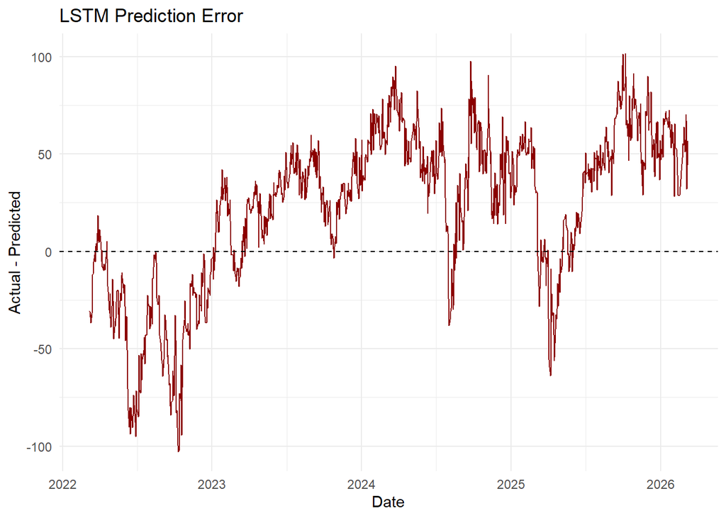

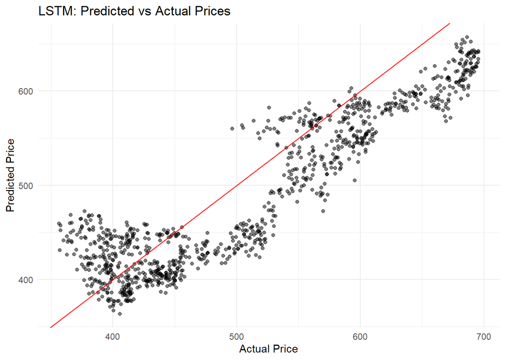

```
[1] 0.4567164
```

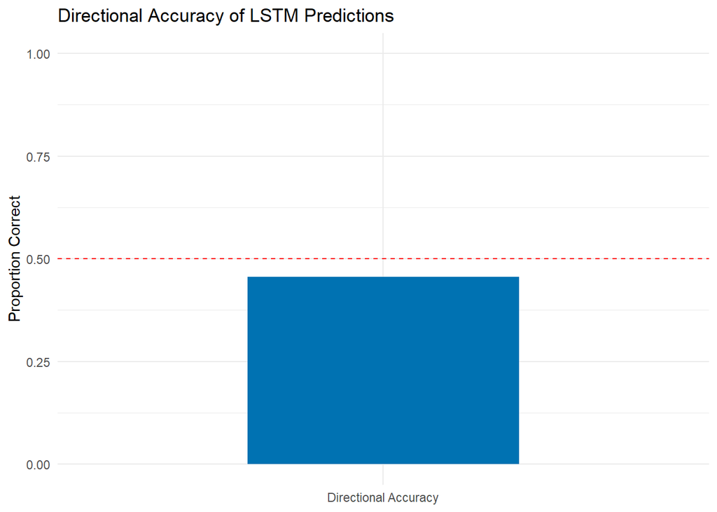

This suggests that restricting the training sample to only recent observations is not necessarily beneficial in financial forecasting. While recent data may better reflect current market conditions, a longer historical sample may still provide important information about broader market behavior, recurring patterns, and different volatility regimes. In that sense, older observations may help stabilize the learning process by exposing the model to a wider range of market environments. The weaker results of the five-year LSTM model therefore indicate that historical data may still play an important role, especially when markets are highly volatile and unpredictable.

In other words, more recent data are not always more informative if they mainly reflect a particularly turbulent market regime. Furthermore, if accurate price prediction models existed, one might question the value of completing my degree and instead start trading immediately.